# Homework 2 template

Tam Nguyen

Thursday 6th, 2018

## 2.37(a-c)

```r
#load data set
data("BaseballTimes")
```

### a.

Calculate the correlations of each predictor var with length of a game (Time). Identify which is strongly correlated.

```r
duration = BaseballTimes$Time
waiting = BaseballTimes$Pitchers
waiting_3 = BaseballTimes$Runs
waiting_4 = BaseballTimes$Margin
waiting_5 = BaseballTimes$Attendance
cor(duration, waiting)
```

```
## [1] 0.8943082
```

```r
cor(duration, waiting_3)
```

```
## [1] 0.6813144
```

```r
cor(duration, waiting_4)
```

```
## [1] -0.07135831
```

```r
cor(duration, waiting_5)
```

```
## [1] 0.2571925
```

- Pitchers var has the strongest correlation to the Time variable.

### b.

Choose the best var. Find regression eq for time. Interpret the slope coefficient of this equations

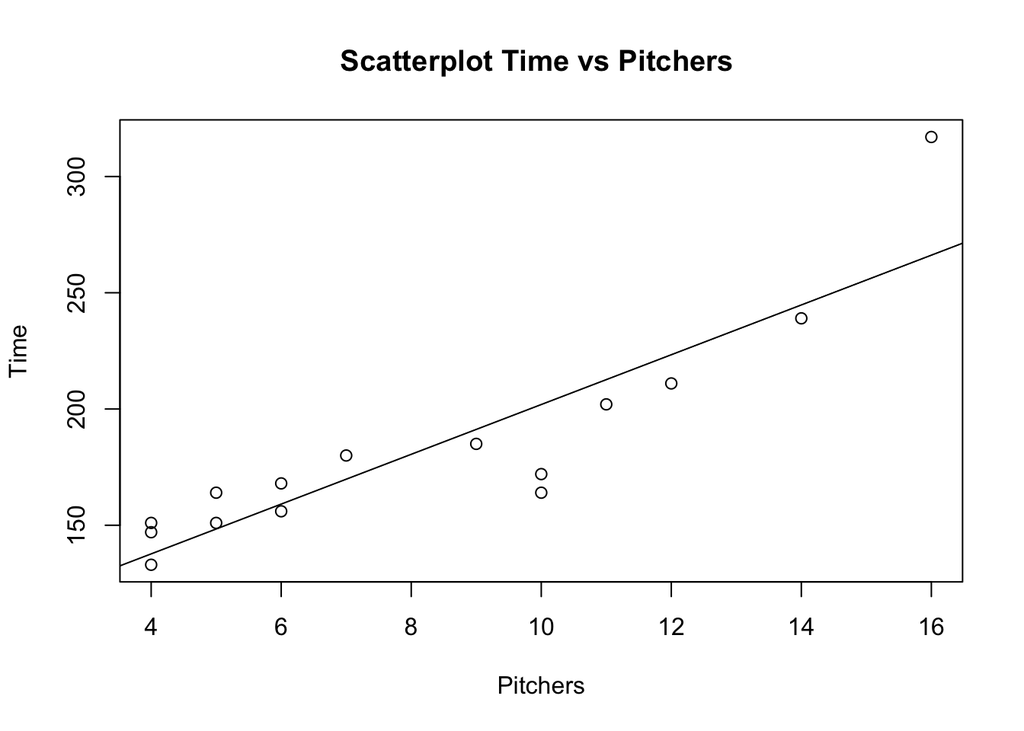

```r
simplereg= lm(Time~Pitchers, data=BaseballTimes) # Create linear line to see the relationship between pitchers and time variable
plot(Time~Pitchers, data = BaseballTimes, main="Scatterplot Time vs Pitchers ")  #Draw scatter points
abline(reg=simplereg) #Draw linear line into graph
```

```r
summary(simplereg)
```

```
##
## Call:
## lm(formula = Time ~ Pitchers, data = BaseballTimes)
##
## Residuals:
##     Min      1Q  Median      3Q     Max
## -37.945  -8.445  -3.104   9.751  50.794
##
## Coefficients:
##             Estimate Std. Error t value Pr(>|t|)
## (Intercept)   94.843     13.387   7.085 8.24e-06 ***
## Pitchers      10.710      1.486   7.206 6.88e-06 ***
## ---
## Signif. codes:  0 '***' 0.001 '**' 0.01 '*' 0.05 '.' 0.1 ' ' 1
##
## Residual standard error: 21.46 on 13 degrees of freedom
## Multiple R-squared:  0.7998, Adjusted R-squared:  0.7844
## F-statistic: 51.93 on 1 and 13 DF,  p-value: 6.884e-06
```

### c.

Perform the appropriate significant test of whether this predictor is really correlated with time in the population

```r
cor.test(~Time+Pitchers, data = BaseballTimes)
```

```
##
##  Pearson's product-moment correlation
##
## data:  Time and Pitchers
## t = 7.2063, df = 13, p-value = 6.884e-06
## alternative hypothesis: true correlation is not equal to 0
## 95 percent confidence interval:
##  0.7050380 0.9646464
## sample estimates:
##       cor
## 0.8943082
```

##1.26

### a.

Produce the relevant scatterplot to investigate the students’ question. Comment on what the scatterplot reveals about the question.

Questions: Whether the number of pages can be used to predict the price?

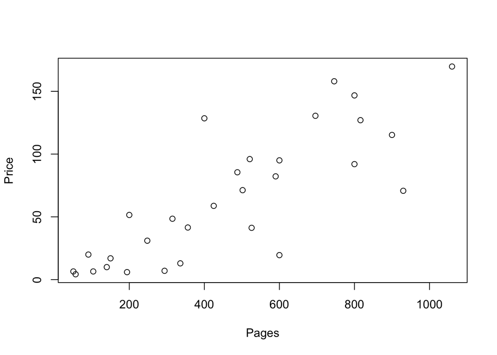

```r
data("TextPrices")
plot(Price~Pages, data = TextPrices)
```

- The scatterplot shows the relationship between Price and Page.
- In the graph, we can see that points mostly compact into a linear line. Howver, there are still many outliners that need further investigation.

### b.

Regression line to predicting price from number of pages

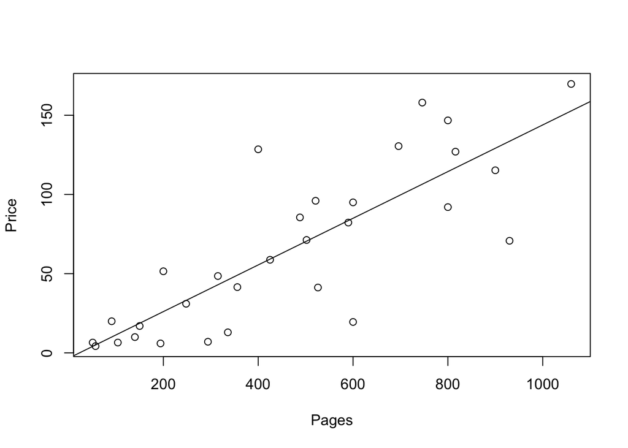

```r
reg = lm (Price~Pages, data = TextPrices)
plot(Price~Pages, data = TextPrices)
abline(reg = reg)
```

### c.

Produce and examine relavant residual plots, and comment on what they reveal about whether the conditions for inference are met with these data

```r
summary(reg)
```

```
##
## Call:
## lm(formula = Price ~ Pages, data = TextPrices)
##
## Residuals:
##     Min      1Q  Median      3Q     Max
## -65.475 -12.324  -0.584  15.304  72.991
##
## Coefficients:
##             Estimate Std. Error t value Pr(>|t|)
## (Intercept) -3.42231   10.46374  -0.327    0.746
## Pages        0.14733    0.01925   7.653 2.45e-08 ***
## ---
## Signif. codes:  0 '***' 0.001 '**' 0.01 '*' 0.05 '.' 0.1 ' ' 1
##
## Residual standard error: 29.76 on 28 degrees of freedom
## Multiple R-squared:  0.6766, Adjusted R-squared:  0.665
## F-statistic: 58.57 on 1 and 28 DF,  p-value: 2.452e-08
```

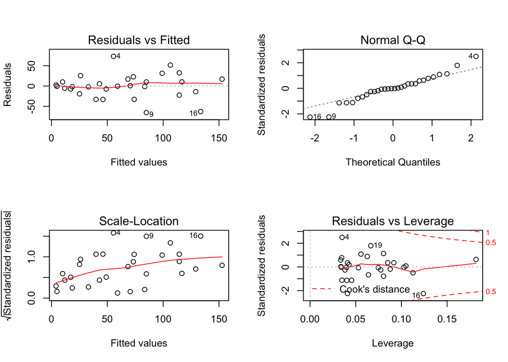

```r
par(mfrow=c(2,2))
plot(reg)
```

Inference Conditions:

- Linearly: Yes, all points are mostly compacted to a linear line
- Constant var: Good
- Normality: Good
- Independant: Randomness

## 2.14

### a.

Perform significant test to address the student’s question of whetther the number of pages is useful predictor of textbook’s price. Report the hypothesis, test statistic, and p-value, along with conclusion.

```r
anova(reg)
```

```
## Analysis of Variance Table
##
## Response: Price
##           Df Sum Sq Mean Sq F value    Pr(>F)
## Pages      1  51877   51877  58.573 2.452e-08 ***
## Residuals 28  24799     886
## ---
## Signif. codes:  0 '***' 0.001 '**' 0.01 '*' 0.05 '.' 0.1 ' ' 1
```

- Our hypothesis is that the number of pages in a textbook has a positive linear relationship with the price of the textbook. In particular, we are testing the model is useful or not. From our summary command, we see that the t-statistic is 7.653 with a statistically significant p-value~0.000. These calculations mean that the number of pages is a useful predictor of textbook price.

### b.

Determine a 95% confidence interval for the population slope coefficient. Explain what slope coefficient means in the context of these data.

```r
confint(reg, level = 0.95)
```

```
##                   2.5 %    97.5 %
## (Intercept) -24.8563229 18.011694
## Pages         0.1078959  0.186761
```

- CI for the population slope coefficient: from 0.1078959 to 0.186761
- This means that we are 95% confident that the population parameter is within the interval [0.1078959, 0.186761]. Similarly, 95% of the data is within the confidence interval.

## 2.15

### a.

Dertermine a 95% confidence interval for the mean price of a 450-page texbook in the population

```r
predict.lm(reg,data.frame("Pages"=450),interval="confidence")
```

```
##        fit      lwr      upr
## 1 62.87549 51.73074 74.02024
```

- The 95% confidence interval for the mean price of a 450-page textbook in the population: 51.73074 ~ 74.02024

### b.

Dertermine a 95% cofidence interval for the price of a particular 450-page texbook in the population.

```r
predict.lm(reg,data.frame("Pages"=450),interval="prediction")
```

```
##        fit       lwr      upr
## 1 62.87549 0.9035981 124.8474
```

- The 95% confidence interval for the individual price of a particular 450-age textbook in the population is: [.90, 124.85].

### c.

How do the midpoints of these two intervals compare? Exlain why this makes sense

- The midpoints of these two interval are equal.
- This makes sense because the two types of intervals are essentially the same except that the prediction interval has a larger standard error. Moreover, both intervals are centered around the single predicted value calculated from the model. Thus, no matter how wide the intervals are, their centers must be equal.

### d.

How do the widths of these two intervals compare? Explain why this make sense.

- The prediction interval is wider than the confidence interval. Prediction intervals must account for both the uncertainty in knowing the value of the population mean, plus data scatter. So a prediction interval is always wider than a confidence interval.

### e.

What value for number of pages would produce the narroest possible prediction interval for its price? Epxlain.

- The mean number of pages, which is 464, would produce the narrowest possible prediction interval for its price because the mean minimizes the standard error in the model.

### f.

Determine a 95% prediction interval for the price of a particular 1500-page textbook in the population. Do you really have 95% cofidence in this interval? Explain.

```r
pages.new1 = data.frame("Pages" = c(1500))
predict(reg, pages.new1, interval="predict")
```

```
##        fit      lwr     upr
## 1 217.5704 143.3587 291.782
```

- The 95% prediction interval for the price of a particular 1500-page textbook in the population is [143.36, 291.78].
- We do not really have 95% confidence in this interval because we are asking the model to predict a price outside of the range of data available. Based on the limited data we have and the model we have created based on that data, we are able to predict that the price of an individual 1500-page textbook is somewhere between [143.36, 291.78], but we are not sure if our model is a good fit for any textbooks with greater than 1060 pages (the maximum number of pages in our population).